# Lab5

Sam Muir

2023-02-07

This week’s lab is a musical lab. You’ll be requesting data from the Spotify API and using it to build k-nearest neighbor and decision tree models.

In order to use the Spotify API you must have a Spotify account. If you don’t have one, sign up for a free one here: https://www.spotify.com/us/signup

Once you have an account, go to Spotify for developers (https://developer.spotify.com/) and log in. Click the green “Create a Client ID” button to fill out the form to create an app create an app so you can access the API.

On your developer dashboard page, click on the new app you just created. Go to Settings -> Basic Information and you will find your Client ID . Click “View client secret” to access your secondary Client ID. Scroll down to Redirect URIs and enter: http://localhost:1410/

You have two options for completing this lab.

**Option 1**: **Classify by users**. Build models that predict whether a given song will be in your collection vs. a partner in class. This requires that you were already a Spotify user so you have enough data to work with. You will download your data from the Spotify API and then exchange with another member of class.

**Option 2**: **Classify by genres**. Build models that predict which genre a song belongs to. This will use a pre-existing Spotify dataset available from Kaggle.com (https://www.kaggle.com/datasets/mrmorj/dataset-of-songs-in-spotify)

```r
knitr::opts_chunk$set(echo = TRUE, warning = FALSE, message = FALSE)
```

```r
library(spotifyr) #API interaction
library(tidyverse)
library(tidymodels)
source(here::here("week-5","keys.R"))
# Modeling packages
library(rpart)       # direct engine for decision tree application
library(caret)       # meta engine for decision tree application

# Model interpretability packages
library(rpart.plot)  # for plotting decision trees
library(vip)         # for feature importance
library(pdp)
library(parsnip)
library(baguette)

library(gt)
library(patchwork)
```

Client ID and Client Secret are required to create and access token that is required to interact with the API. You can set them as system values so we don’t have to do provide them each time.

```r
Sys.setenv(SPOTIFY_CLIENT_ID = SPOTIFY_CLIENT_ID)
Sys.setenv(SPOTIFY_CLIENT_SECRET = SPOTIFY_CLIENT_SECRET)

authorization_code <- get_spotify_authorization_code(scope = scopes()[c(1:19)]) #sets an authorization code that you'll need to provide for certain get_ functions via my_tracks <- get_my_saved_tracks(authorization = authorization_code)

access_token <- get_spotify_access_token() #takes ID and SECRET, sends to Spotify and receives an access token
```

# **Option 1: Data Preparation**

You can use get_my_saved_tracks() to request all your liked tracks. It would be good if you had at least 150-200 liked tracks so the model has enough data to work with. If you don’t have enough liked tracks, you can instead use get_my_recently_played(), and in that case grab at least 500 recently played tracks if you can.

The Spotify API returns a dataframe of tracks and associated attributes. However, it will only return up to 50 (or 20) tracks at a time, so you will have to make multiple requests. Use a function to combine all your requests in one call.

```r
offsets = seq(from = 0, to = 150, by = 50)

#initializing an empty df
my_tracks <- data.frame(matrix(nrow = 0, ncol = 30))

# function to get my 150 most recently liked tracks
for (i in seq_along(offsets)) {
  liked_tracks = get_my_saved_tracks(authorization = authorization_code, limit = 50,
                                     offset = offsets[i])
  df_temp = as.data.frame(liked_tracks) # creating a temporary data frame
  my_tracks <- rbind(my_tracks, df_temp) # binding the temporary data frame to my tracks data frame
}
```

Once you have your tracks, familiarize yourself with this initial dataframe. You’ll need to request some additional information for the analysis. If you give the API a list of track IDs using get_track_audio_features(), it will return an audio features dataframe of all the tracks and some attributes of them.

```r
audio1 <- get_track_audio_features(my_tracks$track.id[1:100])
audio2 <- get_track_audio_features(my_tracks$track.id[101:200])

audio_features <- rbind(audio1, audio2)
```

These track audio features are the predictors we are interested in, but this dataframe doesn’t have the actual names of the tracks. Append the ‘track.name’ column from your favorite tracks database.

```r
sam_audio <- my_tracks %>%
  select(track.name) %>%
  bind_cols(audio_features) %>%
  mutate(name = "sam")

write_csv(sam_audio, "week-5/sam_audio.csv")
```

Find a class mate whose data you would like to use. Add your partner’s data to your dataset. Create a new column that will contain the outcome variable that you will try to predict. This variable should contain two values that represent if the track came from your data set or your partner’s.

```r
sam_audio <- read_csv(here::here("week-5/sam_audio.csv"))
anna_audio <- read_csv(here::here("week-5/named_audio_anna.csv")) %>%
  mutate(name = "anna")

both_audio <- rbind(sam_audio, anna_audio)
```

## Data Exploration

Let’s take a look at your data. Do some exploratory summary stats and visualization.

For example: What are the most danceable tracks in your dataset? What are some differences in the data between users (Option 1) or genres (Option 2)?

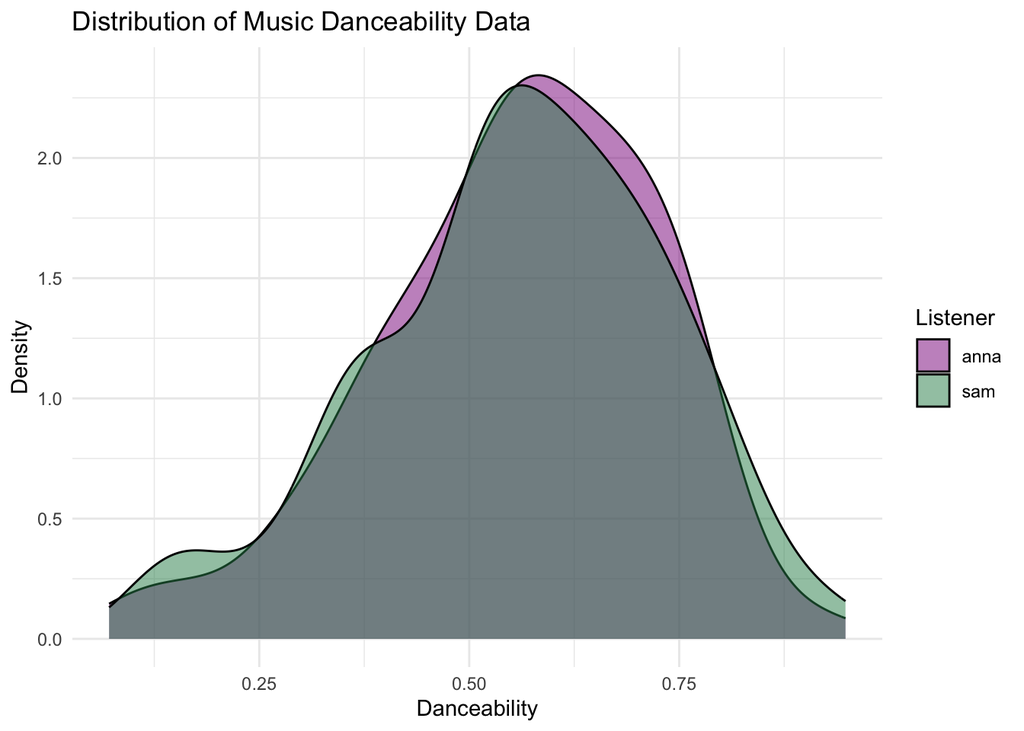

```r
ggplot(both_audio, aes(x = danceability, fill = name)) +
  geom_density(alpha=0.5) +
  scale_fill_manual(values=c("magenta4", "seagreen"))+
  labs(x="Danceability", y="Density", title = "Distribution of Music Danceability Data") +
  guides(fill=guide_legend(title="Listener")) +
  theme_minimal()
```

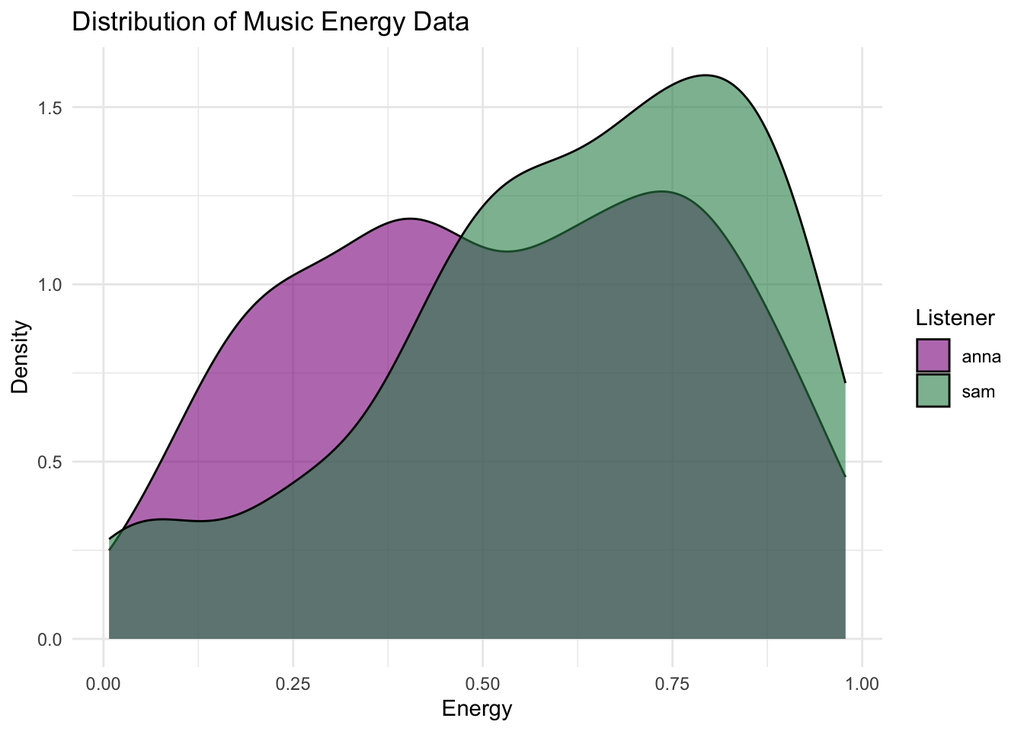

```r
ggplot(both_audio, aes(x = energy, fill = name)) +
  geom_density(alpha=0.6) +
  scale_fill_manual(values=c("magenta4", "seagreen"))+
  labs(x="Energy", y="Density", title = "Distribution of Music Energy Data") +
  guides(fill=guide_legend(title="Listener")) +
  theme_minimal()
```

```r
rbind(anna_audio[which.max(anna_audio$danceability),],
      sam_audio[which.max(sam_audio$danceability),]) %>%
  select(track.name, danceability, name) %>%
  gt::gt(caption = "Liked tracks with the highest danceability")
```

Liked tracks with the highest danceability

| track.name | danceability | name |
| --- | --- | --- |
| Chilling At Nemu's Place | 0.943 | anna |
| Als ich ein Kind war | 0.948 | sam |

# **Modeling**

### Prepare data

```r
# prepare data ----
all_tracks_modeling <- both_audio %>%
  mutate_if(is.ordered, .funs = factor, ordered = F) %>%
  select(-track.name, -type, -id, -uri, -track_href, -analysis_url) %>%
  mutate(name = as.factor(name))

#splitting the data ----
set.seed(123)

tracks_split <- initial_split(all_tracks_modeling, prop = 0.75)
tracks_train <- training(tracks_split)
tracks_test <- testing(tracks_split)

# create a recipe ----
tracks_recipe <- recipe(name ~ ., data = tracks_train) %>%
  step_dummy(all_nominal_predictors()) %>%
  step_normalize(all_numeric_predictors()) %>% #normalize numeric to make sure scale is okay
  prep()
```

Create competing models that predict whether a track belongs to:

Option 1. you or your partner’s collection

You will eventually create four final candidate models:

## 1. k-nearest neighbor (Week 5)

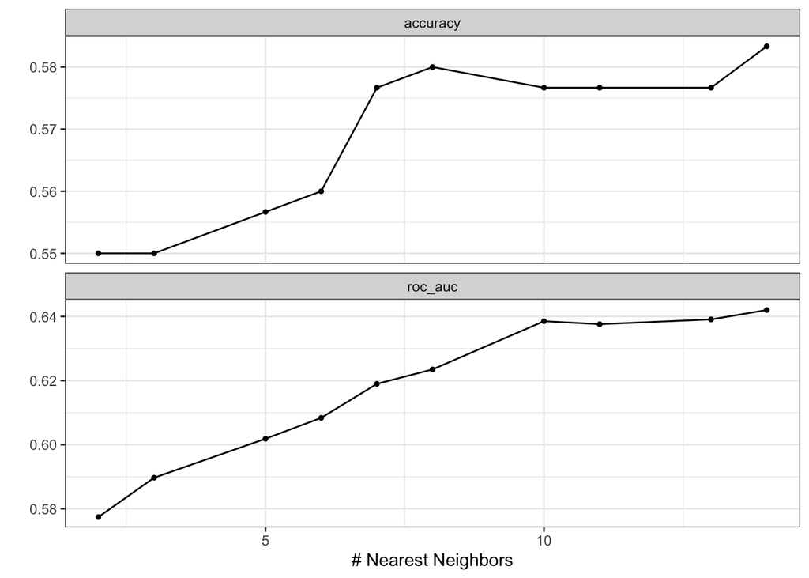

```r
# Define our KNN model with tuning ----
knn_spec_tune <- nearest_neighbor(neighbor = tune()) %>%
  set_mode("classification") %>%
  set_engine("kknn")

# Check the model
#knn_spec_tune

# Define a new workflow ----
wf_knn_tune <- workflow() %>%
  add_model(knn_spec_tune) %>%
  add_recipe(tracks_recipe)

# 10-fold CV on the training dataset ----
set.seed(123)

cv_folds <- tracks_train %>%
  vfold_cv(v = 10)

# Fit the workflow on our predefined folds and hyperparameters ----
fit_knn_cv <- wf_knn_tune %>%
  tune_grid(resamples = cv_folds,
            grid = 10)

# Check the performance with collect_metrics()
#collect_metrics(fit_knn_cv)

# plot cv results for parameter tuning ----
autoplot(fit_knn_cv) +
  theme_bw()
```

```r
# The final workflow for our KNN model ----
final_knn_wf <- wf_knn_tune %>%
  finalize_workflow(select_best(fit_knn_cv, metric = "roc_auc"))

train_knn_fit <- fit(final_knn_wf, tracks_train)

train_predict <- predict(object = train_knn_fit, new_data = tracks_train) %>% #predict the training set
  bind_cols(tracks_train) #bind training set column to prediction

test_knn_predict <- predict(train_knn_fit, tracks_test) %>% #get prediction probabilities for test
  bind_cols(tracks_test) %>%  #bind to testing column
  mutate(name = as.factor(name))

# report the accuracy for the training and testing ----
accuracy(train_predict, truth = name, estimate = .pred_class) #get training accuracy
```

```
## # A tibble: 1 × 3
##   .metric  .estimator .estimate
##   <chr>    <chr>          <dbl>
## 1 accuracy binary         0.823
```

```r
accuracy(test_knn_predict, truth = name, estimate = .pred_class) #get accuracy of testing prediction
```

```
## # A tibble: 1 × 3
##   .metric  .estimator .estimate
##   <chr>    <chr>          <dbl>
## 1 accuracy binary          0.63
```

```r
# sensitivity(train_predict, truth = name, estimate = .pred_class)
# specificity(train_predict, truth = name, estimate = .pred_class)
# sensitivity(test_predict, truth = name, estimate = .pred_class)
# specificity(test_predict, truth = name, estimate = .pred_class)

# Optimizing workflow ----
final_knn_fit <- final_knn_wf %>%
  last_fit(tracks_split)

# last_fit() fit on the training data but then also evaluates on the testing data
final_knn_result <- last_fit(final_knn_wf, tracks_split)

# testing predictions and metrics ----
#final_knn_result$.predictions
knn_predict_data <- as.data.frame(final_knn_result$.predictions) %>%
  bind_cols(tracks_test)

final_knn_result$.metrics
```

```
## [[1]]
## # A tibble: 2 × 4
##   .metric  .estimator .estimate .config
##   <chr>    <chr>          <dbl> <chr>
## 1 accuracy binary         0.63  Preprocessor1_Model1
## 2 roc_auc  binary         0.661 Preprocessor1_Model1
```

## 2. Decision Tree (Week 5)

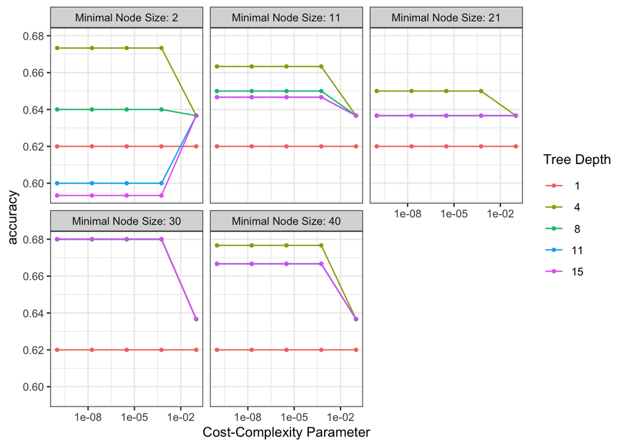

```r
#new spec, tell the model that we are tuning hyperparams ----
tree_spec_tune <- decision_tree(
  cost_complexity = tune(),
  tree_depth = tune(),
  min_n = tune()
) %>%
  set_engine("rpart") %>%
  set_mode("classification")

tree_grid <- grid_regular(cost_complexity(), tree_depth(), min_n(), levels = 5)
#head(tree_grid)

# setting up the workflow ----
wf_tree_tune <- workflow() %>%
  add_recipe(tracks_recipe) %>%
  add_model(tree_spec_tune)

#set up k-fold cv. This can be used for all the algorithms ----
tracks_cv <- tracks_train %>%
  vfold_cv(v=10)
#tracks_cv

# build trees ----
doParallel::registerDoParallel() #build trees in parallel
tree_rs <- tune_grid(
  wf_tree_tune,
  resamples = tracks_cv,
  grid = tree_grid,
  metrics = metric_set(accuracy)
)

# Use autoplot() to examine how different parameter configurations relate to accuracy ----
autoplot(tree_rs) +
  theme_bw()
```

```r
# select hyperparameter ----
#show_best(tree_rs) # showing
select_best(tree_rs) # what we'll input
```

```
## # A tibble: 1 × 4
##   cost_complexity tree_depth min_n .config
##             <dbl>      <int> <int> <chr>
## 1    0.0000000001          4    30 Preprocessor1_Model081
```

```r
# finalize the model specification where we have replaced the tune functions with optimized values ----
final_tree <- finalize_workflow(wf_tree_tune, select_best(tree_rs))
#final_tree

# final fitting ----
final_tree_fit <- fit(final_tree, data = tracks_train)

# last_fit() fit on the training data but then also evaluates on the testing data
final_tree_result <- last_fit(final_tree, tracks_split)

# testing predictions and metrics ----
#final_tree_result$.predictions
final_tree_result$.metrics
```

```
## [[1]]
## # A tibble: 2 × 4
##   .metric  .estimator .estimate .config
##   <chr>    <chr>          <dbl> <chr>
## 1 accuracy binary         0.65  Preprocessor1_Model1
## 2 roc_auc  binary         0.626 Preprocessor1_Model1
```

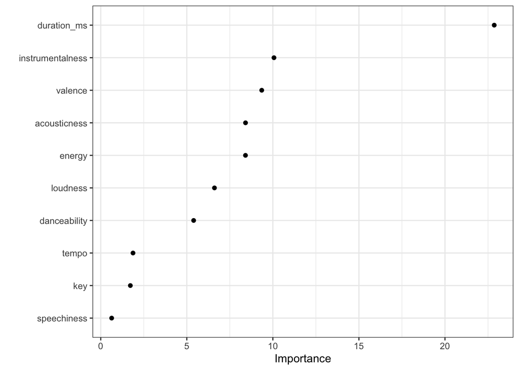

```r
predict_tree_data <- predict(final_tree_fit, tracks_test) %>% #get prediction probabilities for test
  bind_cols(tracks_test) %>%  #bind to testing column
  mutate(name = as.factor(name))

#Visualize variable importance ----
final_tree_fit %>%
  vip(geom = "point") +
  theme_bw()
```

```r
# differences between groups
# ggplot(predict_tree_data, aes(.pred_class, duration_ms)) +
#   geom_boxplot()
```

## 3. bagged tree (Week 6)

```
-   bag_tree()
-   Use the "times =" argument when setting the engine during model specification to specify the number of trees. The rule of thumb is that 50-500 trees is usually sufficient. The bottom of that range should be sufficient here.
```

```r
# set up the bagged tree model ----
bagged_tree <- bag_tree(
  cost_complexity = tune(),
  min_n = tune()
) %>%
  set_engine("rpart", times = 50) %>%
  set_mode("classification")

# workflow ----
wf_bag_tune <- workflow() %>%
  add_recipe(tracks_recipe) %>%
  add_model(bagged_tree)

# set up the tuning ----
bag_grid <- grid_regular(cost_complexity(), min_n(), levels = 5)

bag_rs <- tune_grid(
  wf_bag_tune,
  resamples = tracks_cv,
  grid = bag_grid,
  metrics = metric_set(accuracy))


# select hyperparameter ----
#show_best(bag_rs) # showing
select_best(bag_rs) # what we'll input
```

```
## # A tibble: 1 × 3
##   cost_complexity min_n .config
##             <dbl> <int> <chr>
## 1      0.00000316    11 Preprocessor1_Model08
```

```r
# finalize the model specification ----
final_bag <- finalize_workflow(wf_bag_tune, select_best(bag_rs))
#final_bag

# final fitting ----
final_bag_fit <- fit(final_bag, data = tracks_train)

# last_fit() fit on the training data but then also evaluates on the testing data
final_bag_result <- last_fit(final_bag, tracks_split)

# testing predictions and metrics ----
bag_data <- predict(final_bag_fit, tracks_test) %>% #get prediction probabilities for test
  bind_cols(tracks_test) %>%  #bind to testing column
  mutate(name = as.factor(name))

#final_bag_result$.predictions

# report final metrics ----
final_bag_result$.metrics
```

```
## [[1]]
## # A tibble: 2 × 4
##   .metric  .estimator .estimate .config
##   <chr>    <chr>          <dbl> <chr>
## 1 accuracy binary         0.7   Preprocessor1_Model1
## 2 roc_auc  binary         0.756 Preprocessor1_Model1
```

## 4. Random Forest (Week 6)

```
-   rand_forest()
-   m_try() is the new hyperparameter of interest for this type of model. Make sure to include it in your tuning process
```

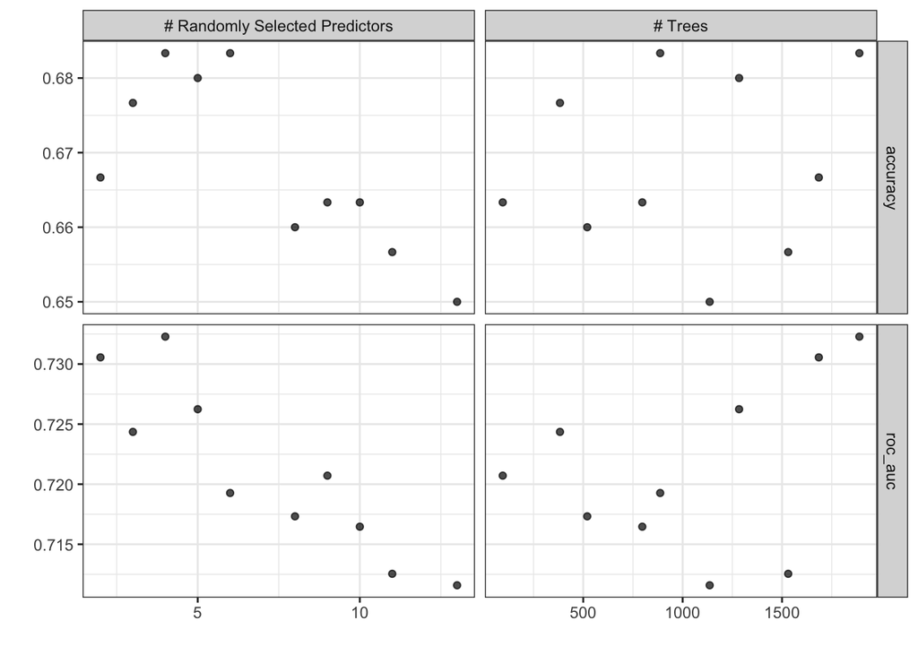

```r
# random forest ----
rf_model <- rand_forest(mtry = tune(),
                  trees = tune()) %>%
  set_engine("ranger") %>%
  set_mode("classification")

# workflow ----
rf_workflow <- workflow() %>%
  add_model(rf_model) %>%
  add_recipe(tracks_recipe)

# parameter tuning ----
rf_cv_tune <- rf_workflow %>%
  tune_grid(resamples = cv_folds, grid = 10) #use cross validation to tune mtry and trees parameters

#get metrics from tuning cv to pick best model ----
#collect_metrics(rf_cv_tune)

#plot cv results for parameter tuning ----
autoplot(rf_cv_tune) +
  theme_bw()
```

```r
# finalize workflow ----
rf_best <- show_best(rf_cv_tune, n = 1, metric = "roc_auc") #get metrics for best random forest model
rf_best
```

```
## # A tibble: 1 × 8
##    mtry trees .metric .estimator  mean     n std_err .config
##   <int> <int> <chr>   <chr>      <dbl> <int>   <dbl> <chr>
## 1     4  1889 roc_auc binary     0.732    10  0.0332 Preprocessor1_Model04
```

```r
rf_final <- finalize_workflow(rf_workflow,
                              select_best(rf_cv_tune, metric = "roc_auc"))

# model fitting ----
train_fit_rf <- fit(rf_final, tracks_train) #fit the KNN model to the training set
#train_fit_rf

# prediction probabilities ----
test_predict_rf <- predict(train_fit_rf, tracks_test) %>% #get prediction probabilities for test
  bind_cols(tracks_test) %>%  #bind to testing column
  mutate(name = as.factor(name))

test_predict2_rf <- predict(train_fit_rf, tracks_test, type = "prob") %>% #get testing prediction
  bind_cols(tracks_test) %>%  #bind to testing column
  mutate(name = as.factor(name))

# model metrics and evaluation
#accuracy(test_predict_rf, truth = name, estimate = .pred_class) #get accuracy of testing prediction

rf_final_result <- last_fit(rf_final, tracks_split)

# testing predictions and metrics ----
#rf_final_result$.predictions
rf_predict_data <- as.data.frame(rf_final_result$.predictions) %>%
  bind_cols(tracks_test)

rf_final_result$.metrics
```

```
## [[1]]
## # A tibble: 2 × 4
##   .metric  .estimator .estimate .config
##   <chr>    <chr>          <dbl> <chr>
## 1 accuracy binary         0.68  Preprocessor1_Model1
## 2 roc_auc  binary         0.769 Preprocessor1_Model1
```

```r
# roc auc curve
test_roc_auc_rf <- roc_curve(test_predict2_rf, name, .pred_anna)
```

# Comparison of model performance

```r
# store the final result metrics
knn_metrics <- final_knn_result$.metrics[[1]]
tree_metrics <- final_tree_result$.metrics[[1]]
bag_metrics <- final_bag_result$.metrics[[1]]
rf_metrics <- rf_final_result$.metrics[[1]]

# combine tmetrics into df for table
comparison_data <- data.frame(
  Model = c("KNN", "Decision Tree", "Bagged Tree", "Random Forest"),
  Accuracy = c(knn_metrics$.estimate[1], tree_metrics$.estimate[1], bag_metrics$.estimate[1], rf_metrics$.estimate[1]),
  ROC_AUC = c(knn_metrics$.estimate[2], tree_metrics$.estimate[2], bag_metrics$.estimate[2], rf_metrics$.estimate[2])
)

# make table
comparison_data %>%
  gt() %>%
  tab_header(
    title = "Model Comparison",
    subtitle = "Accuracy and ROC AUC on Testing Data"
  ) %>%
  fmt_number(
    columns = c(Accuracy, ROC_AUC),
    decimals = 3
  )
```

Model Comparison

Accuracy and ROC AUC on Testing Data

| Model | Accuracy | ROC_AUC |
| --- | --- | --- |
| KNN | 0.630 | 0.661 |
| Decision Tree | 0.650 | 0.626 |
| Bagged Tree | 0.700 | 0.756 |
| Random Forest | 0.680 | 0.769 |

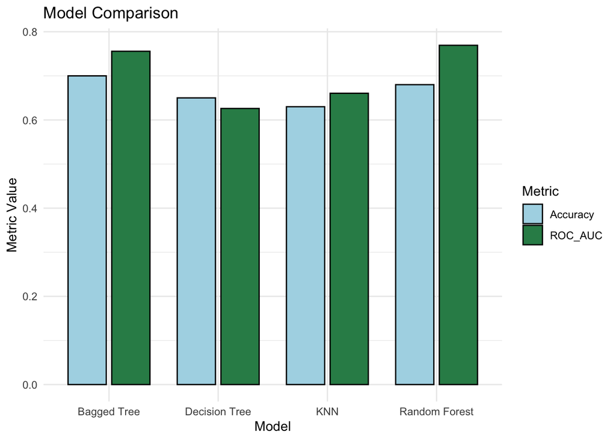

```r
# pivot data for plottig
comparison_data_long <- comparison_data %>%
  pivot_longer(cols = c(Accuracy, ROC_AUC), names_to = "Metric", values_to = "Value")

# plotting
ggplot(comparison_data_long, aes(x = Model, y = Value, fill = Metric)) +
  geom_bar(stat = "identity", position = position_dodge(width = 0.8), width = 0.7, color = "black") +
  labs(title = "Model Comparison",
       y = "Metric Value") +
  theme_minimal() +
  scale_fill_manual(values = c("lightblue", "seagreen"))
```

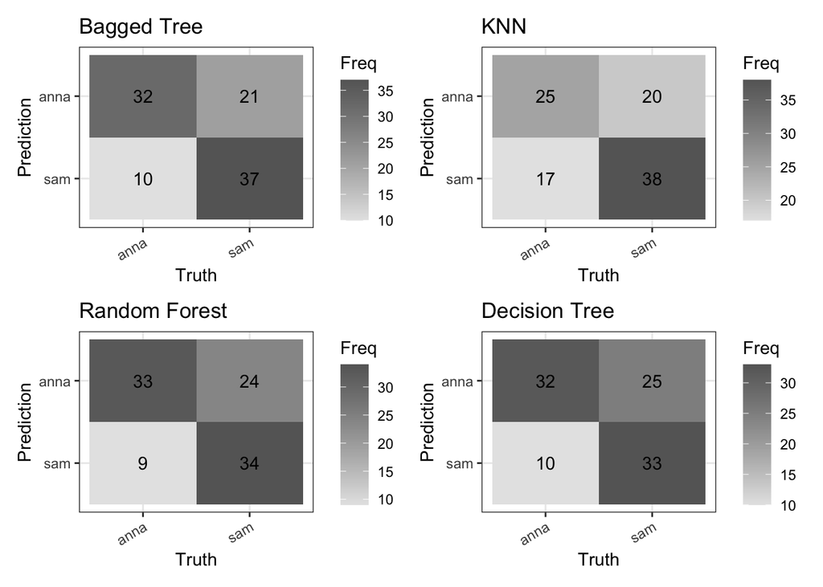

```r
# confusion matrix
knn_conf <- test_knn_predict %>%
  conf_mat(truth = name, estimate = .pred_class) %>%
  autoplot(type = 'heatmap') +
  theme_bw() +
  theme(axis.text.x = element_text(angle = 30, hjust = 1)) +
  labs(title = "KNN")
rf_conf <- test_predict_rf %>%
  conf_mat(truth = name, estimate = .pred_class) %>% #create confusion matrix
  autoplot(type = "heatmap") + #plot confusion matrix with heatmap
  theme_bw() + #change theme
  theme(axis.text.x = element_text(angle = 30, hjust=1)) +
  #rotate axis labels
  labs(title = "Random Forest")
bag_conf <- bag_data %>%
  conf_mat(truth = name, estimate = .pred_class) %>%
  autoplot(type = 'heatmap') +
  theme_bw() +
  theme(axis.text.x = element_text(angle = 30, hjust = 1)) +
  labs(title = "Bagged Tree")
tree_conf <- predict_tree_data %>%
  conf_mat(truth = name, estimate = .pred_class) %>%
  autoplot(type = 'heatmap') +
  theme_bw() +
  theme(axis.text.x = element_text(angle = 30, hjust = 1)) +
  labs(title = "Decision Tree")

bag_conf + knn_conf + rf_conf + tree_conf
```

Go through the modeling process for each model:

Preprocessing. You can use the same recipe for all the models you create.

Resampling. Make sure to use appropriate resampling to select the best version created by each algorithm.

Tuning. Find the best values for each hyperparameter (within a reasonable range).

Compare the performance of the four final models you have created.

Use appropriate performance evaluation metric(s) for this classification task. A table would be a good way to display your comparison. Use at least one visualization illustrating your model results.